# Reproducible Research Assignment #1

Paul Tan

October 1, 2016

## Loading and preprocessing the data

*We shall load the activity data using read.csv() function**

```r
loaded_activity <- read.csv("activity.csv", stringsAsFactors=FALSE)
```

Let’s see our loaded activity data

```r
head(loaded_activity)
```

```
##   steps       date interval
## 1    NA 2012-10-01        0
## 2    NA 2012-10-01        5
## 3    NA 2012-10-01       10
## 4    NA 2012-10-01       15
## 5    NA 2012-10-01       20
## 6    NA 2012-10-01       25
```

**Process/transform the data (if necessary) into a format suitable for your analysis**

```r
#CONVERT ALL DATES IN THE DATASET INTO ACTUAL R DATE FORMAT
loaded_activity$date <- as.POSIXct(loaded_activity$date, format="%Y-%m-%d")

#DETERMINE WEEKDAY AND DAYTYPE DATA COLUMN BASED ON THE ORIGINAL ACTIVITY DATE
loaded_activity <-data.frame(col_date=loaded_activity$date,
                             col_weekday=tolower(weekdays(loaded_activity$date)),
                             col_daytype=ifelse(tolower(weekdays(loaded_activity$date)) == "saturday" |
                                                tolower(weekdays(loaded_activity$date)) == "sunday",                                                          "WEEKEND", "WEEKDAY"),
                             col_steps=loaded_activity$steps,
                             col_interval=loaded_activity$interval)
```

Checking our transformed and cleaned dataset

```r
head(loaded_activity)
```

```
##     col_date col_weekday col_daytype col_steps col_interval
## 1 2012-10-01      monday     WEEKDAY        NA            0
## 2 2012-10-01      monday     WEEKDAY        NA            5
## 3 2012-10-01      monday     WEEKDAY        NA           10
## 4 2012-10-01      monday     WEEKDAY        NA           15
## 5 2012-10-01      monday     WEEKDAY        NA           20
## 6 2012-10-01      monday     WEEKDAY        NA           25
```

## What is mean total number of steps taken per day?

**Calculate the total number of steps taken per day**

```r
#CALCULATE THE SUM OF STEPS GROUP BY ACTIVITY DATE
steps_per_day_summary <- with(loaded_activity,aggregate(loaded_activity$col_steps,
                                              by=list(loaded_activity$col_date),                                                                            na.rm=TRUE, FUN=sum))
#RENAME THE COLUMN
names(steps_per_day_summary) <- c("activity_date", "total_steps")
head(steps_per_day_summary)
```

```
##   activity_date total_steps
## 1    2012-10-01           0
## 2    2012-10-02         126
## 3    2012-10-03       11352
## 4    2012-10-04       12116
## 5    2012-10-05       13294
## 6    2012-10-06       15420
```

Checking our summary data

```r
head(steps_per_day_summary)
```

```
##   activity_date total_steps
## 1    2012-10-01           0
## 2    2012-10-02         126
## 3    2012-10-03       11352
## 4    2012-10-04       12116
## 5    2012-10-05       13294
## 6    2012-10-06       15420
```

**Histogram of the total number of steps taken each day**

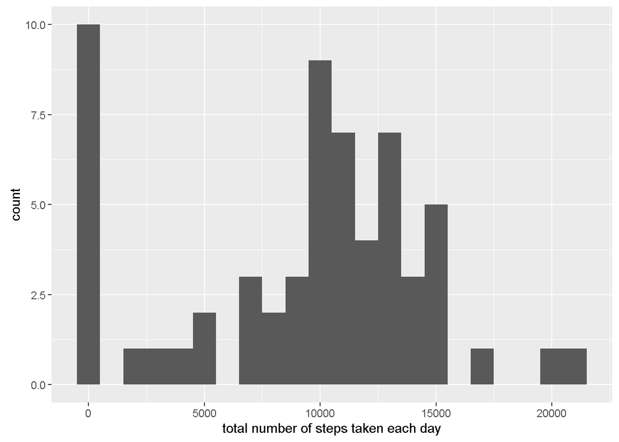

```r
#LOAD THE GGPLOT LIBRARY
library(ggplot2)
#BEGIN PLOTTING THE SUMMARY PLOT
qplot(steps_per_day_summary$total_steps, binwidth=1000, xlab="total number of steps taken each day")
```

**Mean and median number of steps taken each day**

```r
mean(steps_per_day_summary$total_steps)
```

```
## [1] 9354.23
```

```r
median(steps_per_day_summary$total_steps)
```

```
## [1] 10395
```

The required mean value is **9354.2295082** while the median is **10395**

## What is the average daily activity pattern?

**Make a time series plot (i.e. type = “l”) of the 5-minute interval (x-axis) and the average number of steps taken, averaged across all days (y-axis)**

```r
average_steps <- aggregate(loaded_activity$col_steps, by=list(loaded_activity$col_interval),
                 FUN=mean, na.rm=TRUE)
#RENAME THE HEADER OF THE DATASET
names(average_steps) <- c("time_interval", "average_steps")
```

Let’s look at the average_steps data

```r
head(average_steps)
```

```
##   time_interval average_steps
## 1             0     1.7169811
## 2             5     0.3396226
## 3            10     0.1320755
## 4            15     0.1509434
## 5            20     0.0754717
## 6            25     2.0943396
```

Time series plot

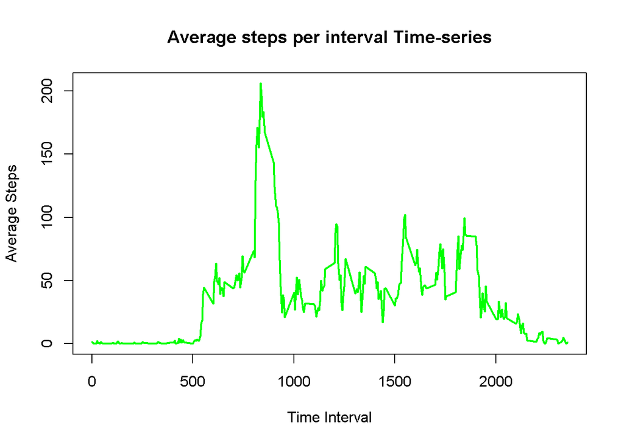

```r
plot(average_steps$time_interval,
     average_steps$average_steps,
     type="l",
     col="green",
     lwd=2,
     xlab="Time Interval",
     ylab="Average Steps",
     main="Average steps per interval Time-series")
```

**Which 5-minute interval, on average across all the days in the dataset, contains the maximum number of steps?**

```r
#GET THE MAXIMUM NUMBER OF STEPS
maximum_avg_steps <- which(average_steps$average_steps == max(average_steps$average_steps))
maximum_interval <- average_steps[maximum_avg_steps, 1]
```

Let’s look at the maximum_interval data

```r
head(maximum_interval)
```

```
## [1] 835
```

## Imputing missing values

```r
#CALCULATE THE TOTAL NUMBER OF ROWS WHICH CONTAIN NA DATA
total_NA_data <- sum(is.na(loaded_activity$col_steps))
```

**Devise a strategy for filling in all of the missing values in the dataset. The strategy does not need to be sophisticated. For example, you could use the mean/median for that day, or the mean for that 5-minute interval, etc.**

```r
Na_data_pos <- which(is.na(loaded_activity$col_steps))

#CREATE VECTOR OF MEANS WITH Na_data_pos AS THE REPETITIVE VALUE
vector_means <- rep(mean(loaded_activity$col_steps, na.rm=TRUE), times=length(Na_data_pos))
```

Let’s look at the vector_means data

```r
head(vector_means)
```

```
## [1] 37.3826 37.3826 37.3826 37.3826 37.3826 37.3826
```

**Create a new dataset that is equal to the original dataset but with the missing data filled in.**

```r
#REPLACE ALL THE NA ROWS WITH VECTORS THAT CONSIST OF MEAN VALUE ON THE ADDITIONAL COLUMN
loaded_activity[Na_data_pos, "col_steps"] <- vector_means
```

```r
head(loaded_activity)
```

```
##     col_date col_weekday col_daytype col_steps col_interval
## 1 2012-10-01      monday     WEEKDAY   37.3826            0
## 2 2012-10-01      monday     WEEKDAY   37.3826            5
## 3 2012-10-01      monday     WEEKDAY   37.3826           10
## 4 2012-10-01      monday     WEEKDAY   37.3826           15
## 5 2012-10-01      monday     WEEKDAY   37.3826           20
## 6 2012-10-01      monday     WEEKDAY   37.3826           25
```

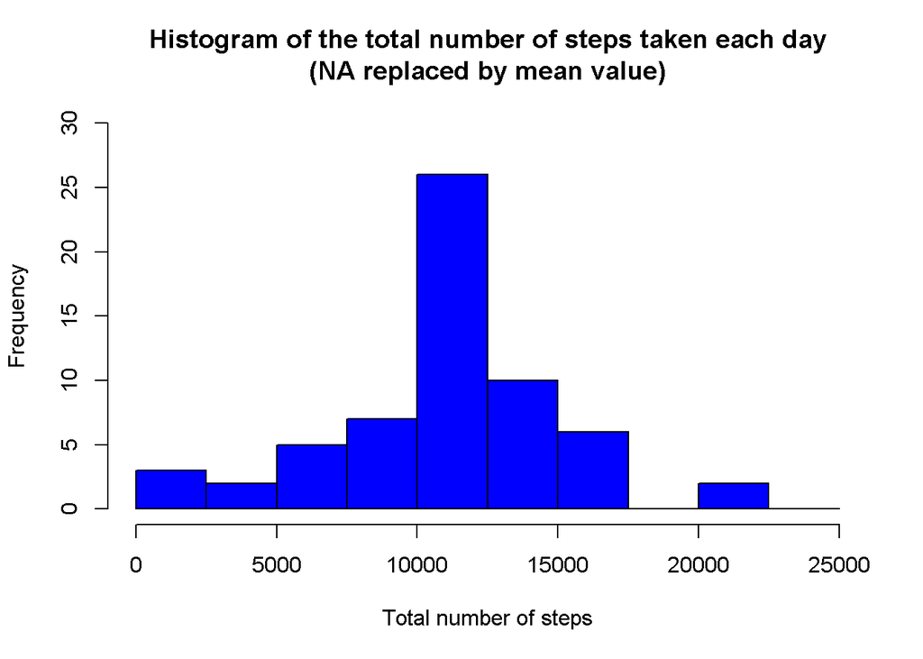

```r
#CALCULATE TOTAL STEPS GROUP BY DAY WITH NA VALUES REMOVED
sum_data <- aggregate(loaded_activity$col_steps, by=list(loaded_activity$col_date), FUN=sum)

#RENAME THE COLUMN
names(sum_data) <- c("date", "total")

# Compute the histogram of the total number of steps each day
hist(sum_data$total,
     breaks=seq(from=0, to=25000, by=2500),
     col="blue",
     xlab="Total number of steps",
     ylim=c(0, 30),
     main="Histogram of the total number of steps taken each day\n(NA replaced by mean value)")
```

## Are there differences in activity patterns between weekdays and weekends?

**For this part the weekdays() function may be of some help here. Use the dataset with the filled-in missing values for this part.**

```r
head(loaded_activity)
```

```
##     col_date col_weekday col_daytype col_steps col_interval
## 1 2012-10-01      monday     WEEKDAY   37.3826            0
## 2 2012-10-01      monday     WEEKDAY   37.3826            5
## 3 2012-10-01      monday     WEEKDAY   37.3826           10
## 4 2012-10-01      monday     WEEKDAY   37.3826           15
## 5 2012-10-01      monday     WEEKDAY   37.3826           20
## 6 2012-10-01      monday     WEEKDAY   37.3826           25
```

**Create a new factor variable in the dataset with two levels - “weekday” and “weekend” indicating whether a given date is a weekday or weekend day.**

```r
#LOAD THE LIBRARY
library(lattice)

#GET THE TOTAL MEAN STEPS GROUP BY DAYTYPE, WEEKDAY AND INTERVAL
average_steps_taken <- aggregate(loaded_activity$col_steps, by=list(loaded_activity$col_daytype,
                               loaded_activity$col_weekday, loaded_activity$col_interval), mean)

#CHANGE THE COLUMN NAME
names(average_steps_taken) <- c("Type", "weekday", "interval", "average_mean")
```

**Make a panel plot containing a time series plot (i.e. type = “l”) of the 5-minute interval (x-axis) and the average number of steps taken, averaged across all weekday days or weekend days (y-axis). See the README file in the GitHub repository to see an example of what this plot should look like using simulated data.**

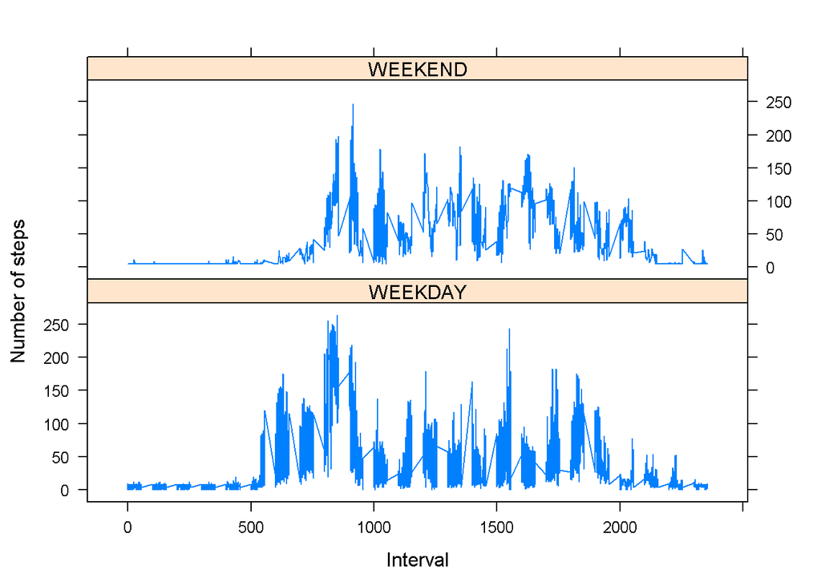

```r
xyplot(average_mean ~ interval | Type, average_steps_taken,
       type="l",
       lwd=1,
       xlab="Interval",
       ylab="Number of steps",
       layout=c(1,2))
```